# Stat 115/215: Introduction to Computational Biology

Lab 1

Andy Shi

1/29/2019 - 1/31/2019

### Introductory Computing

- R/RStudio
  - Download and Install
  - Basic commands
  - Getting Help
- Bioconductor
- Data manipulation
  - Introduction to dplyr
  - filter, summarize, groupby, mean
  - Pipe `%>%`
- Plotting

### Introductory Computing (next week)

- python
- Microarrays
- RMA
- HW1 questions (due Sunday 2/10)

#### Intro to R

This is an R Markdown document that I have output to an HTML presentation. Markdown is a simple formatting syntax for producing HTML, PDF, and MS Word documents. For more details on using R Markdown see http://rmarkdown.rstudio.com.

Each homework will be completed in this format and you will submit both the markdown document with code (.Rmd) and the compiled document (.html). With this format all necessary code (including python code!) may be included in one source and the graders may easily reproduce your results.

Homework files will be provided in several sources depending on thir type/size. Canvas will contain the problem sets and you will submit your completed homework here. GitHub will also contain the problem sets as well as necessary (small) datasets, etc. The Odyssey cluster will contain larger datafiles (/n/stat115/) and will be necessary for high performance computing later in the semester.

But first, let’s get R/RStudio downloaded!

#### Download R/RStudio

[figure not shown]

https://www.rstudio.com/products/rstudio/download/#download

[figure not shown]

Before we get into knitting, let’s consider the concept of a working directory.

```r
# where am I
getwd()

# change where I am (use the RStudio Session > Set Working Directory >
# To Source File Location)
setwd("~/Downloads/")

# list all files
dir()
```

We often want to install packages to add some extra functionality on top of base R (https://cran.r-project.org/). To do so, we need to know the name of the package (often found via a google search) and we need to install it. Once installed, we need to load the package into the namespace.

Let’s try to install the `nycflights13` package.

```r
install.packages("nycflights13")
install.packages("ggplot2")
install.packages("dplyr")
```

Load the packages using the `library` command.

```r
library(nycflights13)
library(ggplot2)
library(dplyr)
```

Now make sure to open the markdown document and follow along! Download either from canvas or from (https://github.com/stat115/Lab1).

#### Quick GitHub Detour

GitHub is a version control system that we will be using primarily as a repository for the homeworks and labs. It is a great tool and we recommend learning and utilizing GitHub for your own work. Lots of tutorials are available such as (https://guides.github.com/activities/hello-world/).

You will only be required to download the homework files and labs but there are many more features worth learning (commiting, branching, etc.). But first, let’s download the lab files.

#### Quick GitHub Detour

- First, register for an account (https://github.com/join)
  - Students get some great extras free for two years as well (https://education.github.com).
- Navigate to the stat115 github page (https://github.com/stat115/)
- Click on the Lab 1 repository
- Click the “Clone or download” button.
  - Either Download Zip and open in finder/explorer. Open in RStudio.
  - Alternatively, copy the URL to the clipboard (https://github.com/stat115/Lab1.git). Switch to RStudio. Click the “Project (None)” button in the near the top menu bar. Click “New Project”, “Version Control”, “Git”, then paste the URL into the first box.
  - Third option, download from Canvas and open/save as a new R markdown file (.Rmd).
- Now this will open up a stylized coding window. Please scroll to $\approx$ line 120

#### R Markdown

To submit your homework you will need to knit the homework .Rmd file and submit both the html and the code.

```r
# we can adjust the size of the text
# Big
## Kinda big
### Still biggish
#### Pretty Normal
```

You can also **bold** or *italicize* text easily. LaTex code may be added inline, such as $\sum_{i=1}^{N} x_i$, as well as inline `code`. Images are very easy to display as well (see above). To suppress code, name chunks, etc. we need to specify the option to the R code chunk. Note that `echo=FALSE` may be added and the code chunk will not be shown at all.

```r
# sample code block
```

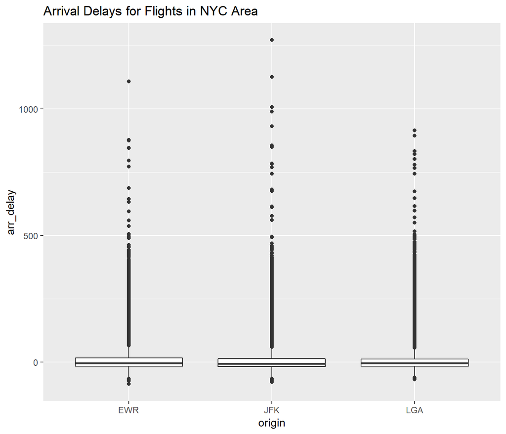

```r
library(ggplot2)
library(dplyr)
flights %>%
    ggplot(aes(x = origin, y = arr_delay)) + geom_boxplot() +
    ggtitle("Arrival Delays for Flights in NYC Area")
```

#### R Markdown

A great cheatsheet is available [here](https://www.rstudio.com/wp-content/uploads/2015/02/rmarkdown-cheatsheet.pdf).

#### Intro to R

Now we will go over basic R commands and data structures.

#### R Vectors

```r
x <- c(1,2,3,4,5) # R is a vectorized language
print(x[1])
```

```
## [1] 1
```

```r
# Operations are performed to each element
x^2
```

```
## [1]  1  4  9 16 25
```

```r
sqrt(x)
```

```
## [1] 1.000000 1.414214 1.732051 2.000000 2.236068
```

```r
y <- x<3 # Vectors may be logical as well
print(y)
```

```
## [1]  TRUE  TRUE FALSE FALSE FALSE
```

#### R Matrices

```r
y <- matrix(1:8,nrow=2,ncol=4,byrow=FALSE) # Create a 2x4 matrix
y[1,2] # Access first row second column
```

```
## [1] 3
```

```r
y[,2] # Access the second column
```

```
## [1] 3 4
```

```r
dim(y) # Size of y
```

```
## [1] 2 4
```

```r
y %*% t(y) # Matrix multiplication
```

```
##      [,1] [,2]
## [1,]   84  100
## [2,]  100  120
```

#### R Data Frames

```r
policy.number <- c("A00187", "A00300","A00467","A01226")
issue.age <- c(74,30,68,74)
sex <- c("F", "M", "M", "F")
smoke <- c("S","N","N","N")
face.amount <- c(420, 1560, 960, 1190)
ins.df <- data.frame(policy.number, issue.age, sex, smoke, face.amount) # Create it

ins.df[1,] # access first row
```

```
##   policy.number issue.age sex smoke face.amount
## 1        A00187        74   F     S         420
```

```r
ins.df[,1] # access first column
```

```
## [1] A00187 A00300 A00467 A01226
## Levels: A00187 A00300 A00467 A01226
```

```r
ins.df$policy.number # access policy number column
```

```
## [1] A00187 A00300 A00467 A01226
## Levels: A00187 A00300 A00467 A01226
```

```r
colnames(ins.df) # column names
```

```
## [1] "policy.number" "issue.age"     "sex"           "smoke"
## [5] "face.amount"
```

```r
dim(ins.df)
```

```
## [1] 4 5
```

#### Getting Help

- `?` command, e.g. `?median`
- Google

#### Bioconductor

We already discussed how to install and load libraries coming from CRAN. However, often we will want to install packages from other sources. In computational biology, many of these will come from Bioconductor.

The process is much the same, but now we need to tell R to look in there instead of a CRAN mirror.

```r
if (!requireNamespace("BiocManager", quietly = TRUE))
    install.packages("BiocManager")
BiocManager::install("affy", version = "3.8")
```

Once it’s been downloaded we can simply load it via the library call.

```r
library(affy)
```

#### Intro to dplyr package

- `dplyr` is an R package that makes it really easy and intuitive to manipulate data.
- Data science (and computational biology) is 80% data cleaning, 20% analysis.
- Material taken from dplyr vignette: https://cran.r-project.org/web/packages/dplyr/vignettes/dplyr.html

#### filter

- Select specific rows based on conditions.

```r
filter(flights, month == 1, day == 1)
```

```
## # A tibble: 842 x 19
##     year month   day dep_time sched_dep_time dep_delay arr_time
##    <int> <int> <int>    <int>          <int>     <dbl>    <int>
##  1  2013     1     1      517            515         2      830
##  2  2013     1     1      533            529         4      850
##  3  2013     1     1      542            540         2      923
##  4  2013     1     1      544            545        -1     1004
##  5  2013     1     1      554            600        -6      812
##  6  2013     1     1      554            558        -4      740
##  7  2013     1     1      555            600        -5      913
##  8  2013     1     1      557            600        -3      709
##  9  2013     1     1      557            600        -3      838
## 10  2013     1     1      558            600        -2      753
## # ... with 832 more rows, and 12 more variables: sched_arr_time <int>,
## #   arr_delay <dbl>, carrier <chr>, flight <int>, tailnum <chr>,
## #   origin <chr>, dest <chr>, air_time <dbl>, distance <dbl>, hour <dbl>,
## #   minute <dbl>, time_hour <dttm>
```

#### select

- Select specific columns

```r
select(flights, year, month, day)
```

```
## # A tibble: 336,776 x 3
##     year month   day
##    <int> <int> <int>
##  1  2013     1     1
##  2  2013     1     1
##  3  2013     1     1
##  4  2013     1     1
##  5  2013     1     1
##  6  2013     1     1
##  7  2013     1     1
##  8  2013     1     1
##  9  2013     1     1
## 10  2013     1     1
## # ... with 336,766 more rows
```

#### mutate

- Add new columns

```r
mutate(flights,
  gain = arr_delay - dep_delay,
  speed = distance / air_time * 60
)
```

```
## # A tibble: 336,776 x 21
##     year month   day dep_time sched_dep_time dep_delay arr_time
##    <int> <int> <int>    <int>          <int>     <dbl>    <int>
##  1  2013     1     1      517            515         2      830
##  2  2013     1     1      533            529         4      850
##  3  2013     1     1      542            540         2      923
##  4  2013     1     1      544            545        -1     1004
##  5  2013     1     1      554            600        -6      812
##  6  2013     1     1      554            558        -4      740
##  7  2013     1     1      555            600        -5      913
##  8  2013     1     1      557            600        -3      709
##  9  2013     1     1      557            600        -3      838
## 10  2013     1     1      558            600        -2      753
## # ... with 336,766 more rows, and 14 more variables: sched_arr_time <int>,
## #   arr_delay <dbl>, carrier <chr>, flight <int>, tailnum <chr>,
## #   origin <chr>, dest <chr>, air_time <dbl>, distance <dbl>, hour <dbl>,
## #   minute <dbl>, time_hour <dttm>, gain <dbl>, speed <dbl>
```

#### arrange

- Sort dataframe by columns.

```r
arrange(flights, year, month, day)
```

```
## # A tibble: 336,776 x 19
##     year month   day dep_time sched_dep_time dep_delay arr_time
##    <int> <int> <int>    <int>          <int>     <dbl>    <int>
##  1  2013     1     1      517            515         2      830
##  2  2013     1     1      533            529         4      850
##  3  2013     1     1      542            540         2      923
##  4  2013     1     1      544            545        -1     1004
##  5  2013     1     1      554            600        -6      812
##  6  2013     1     1      554            558        -4      740
##  7  2013     1     1      555            600        -5      913
##  8  2013     1     1      557            600        -3      709
##  9  2013     1     1      557            600        -3      838
## 10  2013     1     1      558            600        -2      753
## # ... with 336,766 more rows, and 12 more variables: sched_arr_time <int>,
## #   arr_delay <dbl>, carrier <chr>, flight <int>, tailnum <chr>,
## #   origin <chr>, dest <chr>, air_time <dbl>, distance <dbl>, hour <dbl>,
## #   minute <dbl>, time_hour <dttm>
```

#### desc

- Use `desc` to sort by descending order.

```r
arrange(flights, desc(arr_delay))
```

```
## # A tibble: 336,776 x 19
##     year month   day dep_time sched_dep_time dep_delay arr_time
##    <int> <int> <int>    <int>          <int>     <dbl>    <int>
##  1  2013     1     9      641            900      1301     1242
##  2  2013     6    15     1432           1935      1137     1607
##  3  2013     1    10     1121           1635      1126     1239
##  4  2013     9    20     1139           1845      1014     1457
##  5  2013     7    22      845           1600      1005     1044
##  6  2013     4    10     1100           1900       960     1342
##  7  2013     3    17     2321            810       911      135
##  8  2013     7    22     2257            759       898      121
##  9  2013    12     5      756           1700       896     1058
## 10  2013     5     3     1133           2055       878     1250
## # ... with 336,766 more rows, and 12 more variables: sched_arr_time <int>,
## #   arr_delay <dbl>, carrier <chr>, flight <int>, tailnum <chr>,
## #   origin <chr>, dest <chr>, air_time <dbl>, distance <dbl>, hour <dbl>,
## #   minute <dbl>, time_hour <dttm>
```

#### summarize

- Take many numbers and condense them into 1 number.

```r
summarise(flights,
  delay = mean(dep_delay, na.rm = TRUE)
)
```

```
## # A tibble: 1 x 1
##   delay
##   <dbl>
## 1  12.6
```

#### group_by

- The true power of dplyr comes into play when we can perform grouped operations.
- First, group by plane. Then, summarize the number of flights, average distance, and average delay.

```r
by_tailnum <- group_by(flights, tailnum)
delay <- summarise(by_tailnum,
  count = n(),
  dist = mean(distance, na.rm = TRUE),
  arr_delay = mean(arr_delay, na.rm = TRUE))
delay <- filter(delay, count > 20, dist < 2000)
delay
```

```
## # A tibble: 2,962 x 4
##    tailnum count  dist arr_delay
##    <chr>   <int> <dbl>     <dbl>
##  1 N0EGMQ    371  676.     9.98
##  2 N10156    153  758.    12.7
##  3 N102UW     48  536.     2.94
##  4 N103US     46  535.    -6.93
##  5 N104UW     47  535.     1.80
##  6 N10575    289  520.    20.7
##  7 N105UW     45  525.    -0.267
##  8 N107US     41  529.    -5.73
##  9 N108UW     60  534.    -1.25
## 10 N109UW     48  536.    -2.52
## # ... with 2,952 more rows
```

#### The pipe, part 1

When you manipulate data with dplyr, you always have to save the result to a new variable.

```r
a1 <- group_by(flights, year, month, day)
a2 <- select(a1, arr_delay, dep_delay)
a3 <- summarise(a2,
  arr = mean(arr_delay, na.rm = TRUE),
  dep = mean(dep_delay, na.rm = TRUE))
a4 <- filter(a3, arr > 30 | dep > 30)
```

#### The pipe, part 2

If you don’t want to rename intermediate results, you have to wrap the function calls inside each other:

```r
filter(
  summarise(
    select(
      group_by(flights, year, month, day),
      arr_delay, dep_delay
    ),
    arr = mean(arr_delay, na.rm = TRUE),
    dep = mean(dep_delay, na.rm = TRUE)
  ),
  arr > 30 | dep > 30
)
```

```
## # A tibble: 49 x 5
## # Groups:   year, month [11]
##     year month   day   arr   dep
##    <int> <int> <int> <dbl> <dbl>
##  1  2013     1    16  34.2  24.6
##  2  2013     1    31  32.6  28.7
##  3  2013     2    11  36.3  39.1
##  4  2013     2    27  31.3  37.8
##  5  2013     3     8  85.9  83.5
##  6  2013     3    18  41.3  30.1
##  7  2013     4    10  38.4  33.0
##  8  2013     4    12  36.0  34.8
##  9  2013     4    18  36.0  34.9
## 10  2013     4    19  47.9  46.1
## # ... with 39 more rows
```

#### The pipe, part 3

But this can be hard to read, since we are going inside-out. Instead, we can use the `%>%` command, which turns `f(x, y)` into `x %>% f(y)`. This is much easier to read.

```r
flights %>%
  group_by(year, month, day) %>%
  select(arr_delay, dep_delay) %>%
  summarise(
    arr = mean(arr_delay, na.rm = TRUE),
    dep = mean(dep_delay, na.rm = TRUE)
  ) %>%
  filter(arr > 30 | dep > 30)
```

```
## # A tibble: 49 x 5
## # Groups:   year, month [11]
##     year month   day   arr   dep
##    <int> <int> <int> <dbl> <dbl>
##  1  2013     1    16  34.2  24.6
##  2  2013     1    31  32.6  28.7
##  3  2013     2    11  36.3  39.1
##  4  2013     2    27  31.3  37.8
##  5  2013     3     8  85.9  83.5
##  6  2013     3    18  41.3  30.1
##  7  2013     4    10  38.4  33.0
##  8  2013     4    12  36.0  34.8
##  9  2013     4    18  36.0  34.9
## 10  2013     4    19  47.9  46.1
## # ... with 39 more rows
```

#### group_by example

- What is this code doing?

```r
flights %>% filter(origin == "EWR") %>%
    group_by(dest) %>%
    summarize(n = n()) %>%
    arrange(desc(n))
```

```
## # A tibble: 86 x 2
##    dest      n
##    <chr> <int>
##  1 ORD    6100
##  2 BOS    5327
##  3 SFO    5127
##  4 CLT    5026
##  5 ATL    5022
##  6 MCO    4941
##  7 LAX    4912
##  8 IAH    3973
##  9 FLL    3793
## 10 DTW    3178
## # ... with 76 more rows
```

#### Plotting

- We will use `ggplot` from the `ggplot2` package.

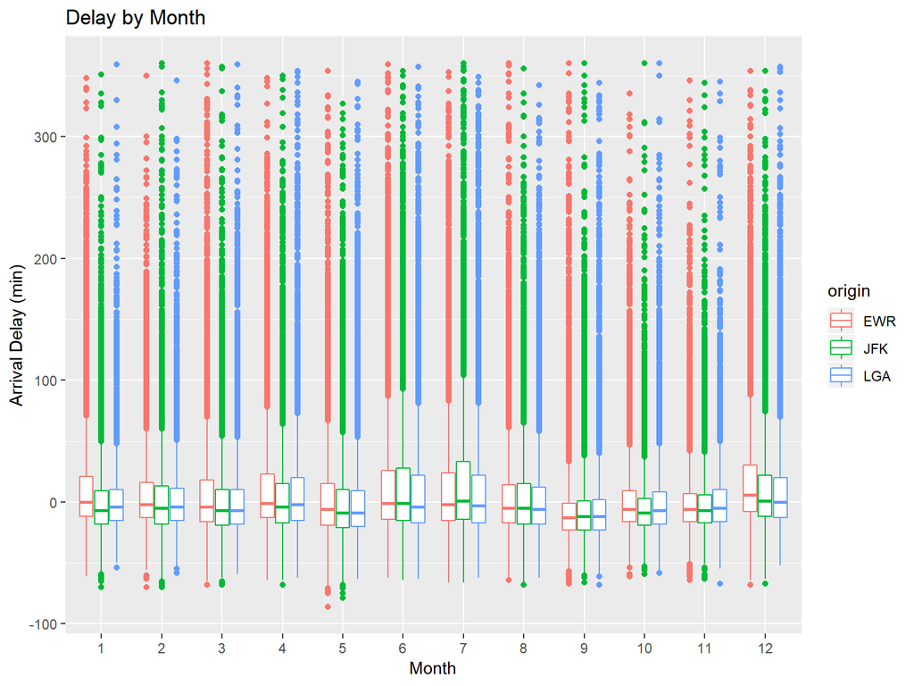

```r
flights %>%
    filter(arr_delay <= 360) %>%
    ggplot(aes(x = factor(month), y = arr_delay, color = origin)) +
    geom_boxplot() +
    ggtitle("Delay by Month") +
    xlab("Month") +
    ylab("Arrival Delay (min)")
```

#### Plotting

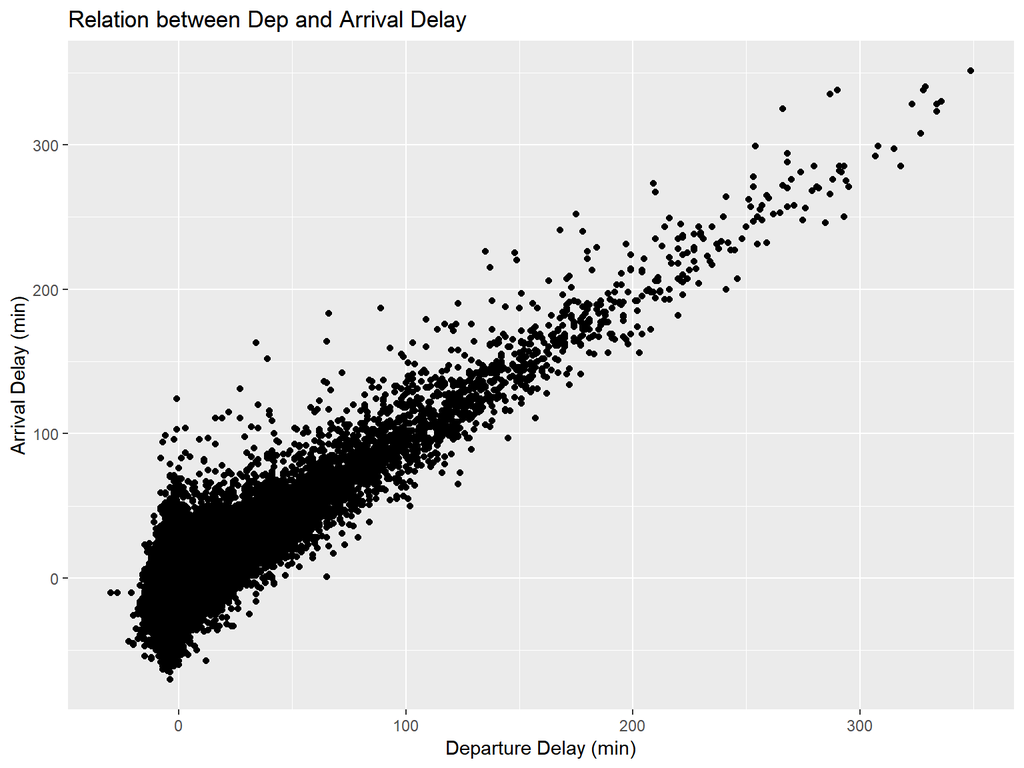

```r
flights %>%
    filter(month == 1, arr_delay < 360, dep_delay < 360) %>%
    ggplot(aes(x = dep_delay, y = arr_delay)) +
    geom_point() +
    ggtitle("Relation between Dep and Arrival Delay") +
    xlab("Departure Delay (min)") +
    ylab("Arrival Delay (min)")
```